# project3

Adarsh Ramanujam

2025-11-25

# Introduction

# Background

In August 2025, the USHHS (US Health and Human Services Department) said that they were discontinuing 22 mRNA vaccines that terminated production of new flu and COVID vaccines from companies like Pfizer and Safoni Pasteur (Source: USHHS). Additionally, with the spread of misinformation about the benefits and the harms of vaccines floating around in online spaces like X, Instagram, Facebook, etc, I wanted to examine whether the relation between unvaccinated people specifically against the flu had a positive or negative correlation with higher deaths rates per population within the county, and whether confounding factors like socioeconomic status, which would limit the amount of healthcare people in a lower earning county may be able to obtain, would affect it more (which I suspect will also contribute to vaccination rate as well). According to the NIH, during COVID, once both lower and higher socioeconomic counties had a relatively equal access to COVID vaccines, the unvaccinated people started dying at twice the rate of the vaccinated people, as they didn’t have the necessary antibodies to fight back. According to the American Academy of Allergy Asthma and Immunology, they also help with maintaining herd immunity against deadly diseases like measles and pertussis (which have reemerged as of late). This study will either draw a similar conclusion to the NIH, which will be my main hypothesis, that the rate of vaccinations will directly correspond to rate of death within a county regardless of confounding factors.

# Data

## Loading the Data

```r
library(sf)
library(tidyverse)
library(tmap)
library(tigris)
```

```r
library(ggplot2)
library(arcpullr)
```

In the following blocks of code, I clean and prep the data to use later on.

```r
nationalHealthData <- read.csv("https://drive.google.com/uc?export=view&id=1SkhzlEZJyRiCIoV69ws5s29X6j73IamO")

nc_counties_map <- counties('NC')
```

[output not shown]

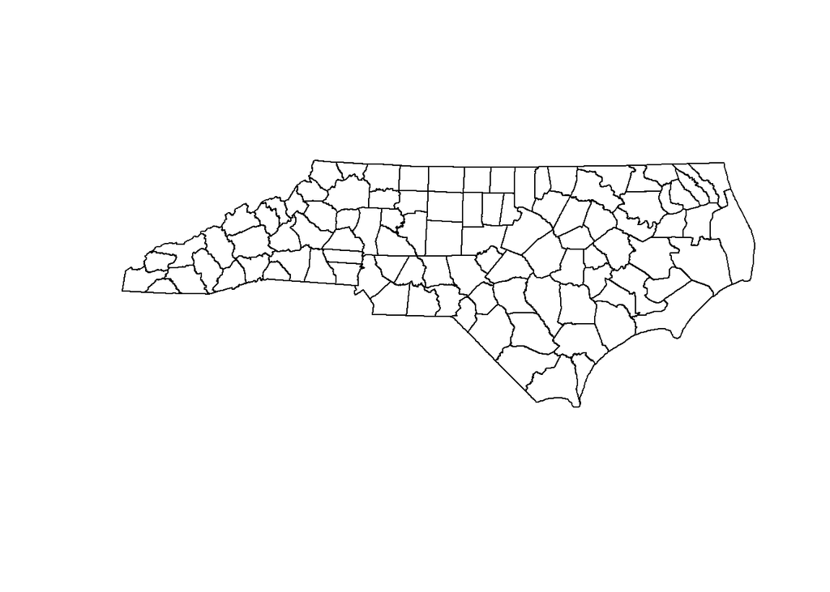

```r
nc_counties_map <- st_transform(nc_counties_map, "EPSG:32119")
plot(nc_counties_map$geometry)
```

```r
nationalHealthData <- nationalHealthData |>
  filter(X.1 == 'North Carolina')

nationalHealthData <- nationalHealthData[-1, ]
```

```r
names(nationalHealthData)[names(nationalHealthData) == 'X.2'] <- 'NAME'

nc_health_map <- nc_counties_map |>
  inner_join(nationalHealthData, by='NAME')

nc_health_map <- nc_health_map |>
    filter(X.1 == 'North Carolina')
```

The following map shows the vaccination rates across the NC counties.

```r
  nc_health_map |>
  tm_shape(nc_counties_map) +
  tm_polygons(fill= 'Flu.Vaccinations',
              style="jenks",
              n = 7,
              title="% Flu Vaccinated (Jenks)\n2020-2025 USCHR",
              palette="Purples"
  ) +
  tm_layout(frame = TRUE,
            frame.color = "White",
            outer.margins=0,
            legend.position = tm_pos_out("right", "center"),
            legend.frame = TRUE,
            legend.frame.color = "White",
            title = "% Flu Vaccinated",
            title.position = tm_pos_out("center", "top")
  ) +
  tm_credits("Adarsh Ramanujam, November 25th\nData: USCHR\nGEOG 215",
             position = tm_pos_in("left", "bottom"))
```

```
## ── tmap v3 code detected ───────────────────────────────────────────────────────
```

[output not shown]

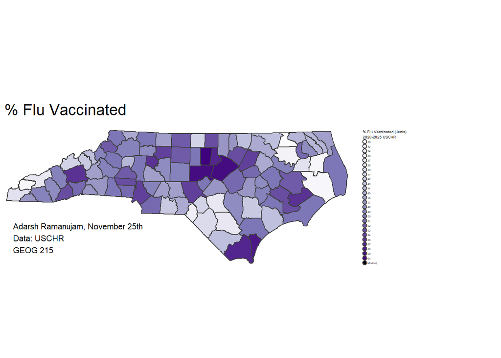

As we can see, there is much variability within the state of NC for the rate of vaccinations. According to the original dataset, there is an average of 51% of vaccinations throughout the state.

Now, we will look at the death rates across the state.

```r
ncCounties <- read_sf("https://drive.google.com/uc?export=download&id=1Ks38Gmdlp58GBhOgb6FBmx8tIAfu0QDw")

ncCounties <- ncCounties |>
  mutate(NAME = str_remove(NAME, " County, North Carolina"))

ncCounties_data <- st_drop_geometry(ncCounties)

nc_health_map <- nc_health_map |>
  inner_join(ncCounties_data, by = 'NAME')

library(stringr)

nc_health_map <- nc_health_map |>
  mutate(X.3 = str_remove_all(X.3, ","),
         X.3 = as.numeric(X.3)) |>

  mutate(death_rate = X.3 / popE * 100)
```

```r
  nc_health_map |>
  tm_shape(nc_counties_map) +
  tm_polygons(fill= 'death_rate',
              style="jenks",
              n = 7,
              title="Death Rate in NC (Jenks)\n2020-2025 USCHR",
              palette="Reds"
  ) +
  tm_layout(frame = TRUE,
            frame.color = "White",
            outer.margins=0,
            legend.position = tm_pos_out("right", "center"),
            legend.frame = TRUE,
            legend.frame.color = "White",
            title = "Death Rate in NC",
            title.position = tm_pos_out("center", "top")
  ) +
  tm_credits("Adarsh Ramanujam, November 25th\nData: USCHR\nGEOG 215",
             position = tm_pos_in("left", "bottom"))
```

```
## ── tmap v3 code detected ───────────────────────────────────────────────────────
```

[output not shown]

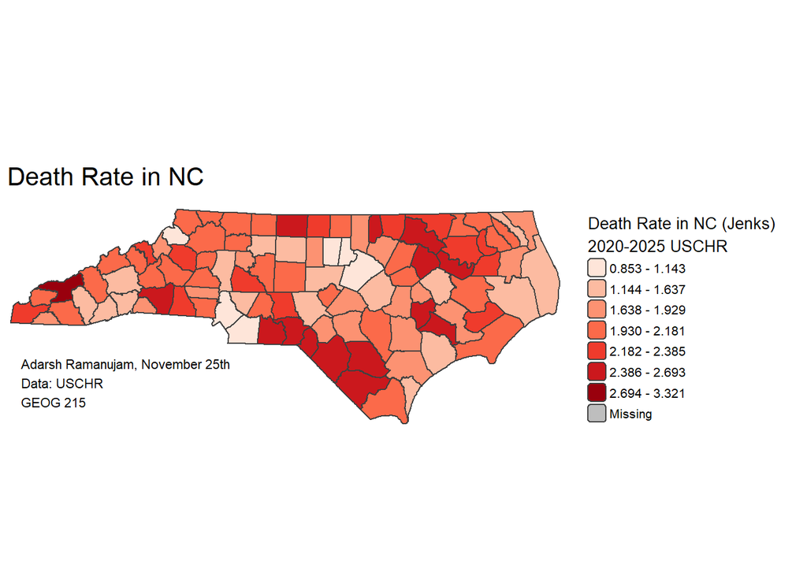

As we can visually see, there is definitely some slight inverse correlation between the vaccinations and death rates by observing with our eyes, but I’m still not convinced. Let’s continue with our linear regression to see if there is a concrete relation between the two.

# Methods

Here, we will test for the linear regression relation between vaccination rates, death rates, and income using multiple linear regressions.

This first graph will be one comparing median income and death rate per county.

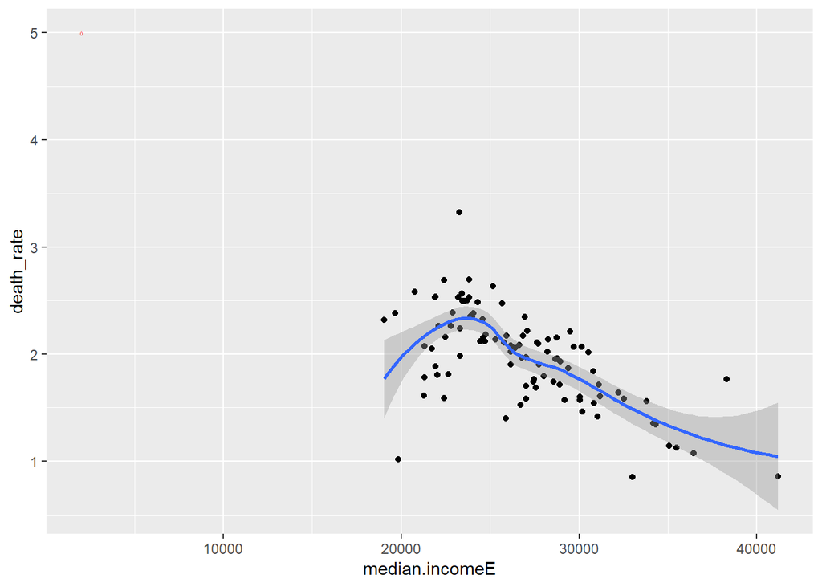

```r
model1 <- lm(death_rate ~ median.incomeE, data=nc_health_map)
slope1 <- round(coef(model1)[2], digits=3)

nc_health_map |>
  ggplot(aes(x=median.incomeE, y=death_rate)) +
  geom_point() +
  geom_smooth() +
  annotate("text", label=slope1, x=2000, y=5, size=1, color="red")
```

```r
first.model.county <- lm(death_rate ~ median.incomeE, data=nc_health_map)
summary(first.model.county)
```

```
##
## Call:
## lm(formula = death_rate ~ median.incomeE, data = nc_health_map)
##
## Residuals:
##      Min       1Q   Median       3Q      Max
## -1.41478 -0.17132  0.02812  0.20492  1.11616
##
## Coefficients:
##                  Estimate Std. Error t value Pr(>|t|)
## (Intercept)     3.724e+00  2.154e-01  17.287  < 2e-16 ***
## median.incomeE -6.522e-05  7.947e-06  -8.207 9.15e-13 ***
## ---
## Signif. codes:  0 '***' 0.001 '**' 0.01 '*' 0.05 '.' 0.1 ' ' 1
##
## Residual standard error: 0.3334 on 98 degrees of freedom
## Multiple R-squared:  0.4073, Adjusted R-squared:  0.4013
## F-statistic: 67.36 on 1 and 98 DF,  p-value: 9.154e-13
```

The r-square value is 0.4013, which means that 40.13% of the variation of the data can be represented by the model. The p value of much less than 0.05 (9.15*10^-13), signifies that the data is statistically significant.

Let’s see the relation between death rate and vaccination rate for the flu.

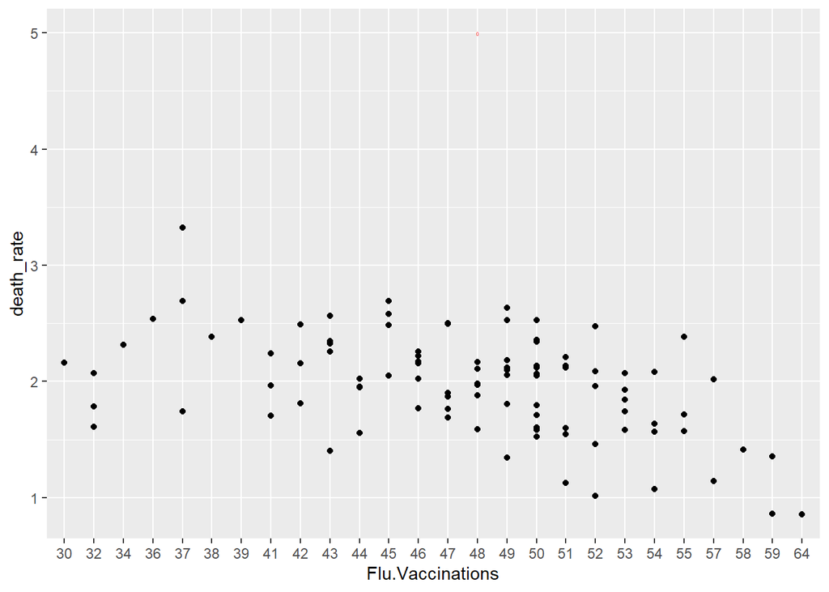

```r
model2 <- lm(death_rate ~ Flu.Vaccinations, data=nc_health_map)
slope2 <- round(coef(model1)[2], digits=3)

nc_health_map |>
  ggplot(aes(x=Flu.Vaccinations, y=death_rate)) +
  geom_point() +
  geom_smooth() +
  annotate("text", label=slope2, x=15, y=5, size=1, color="red")
```

```r
second.model.county <- lm(death_rate ~ Flu.Vaccinations, data=nc_health_map)
summary(second.model.county)
```

```
##
## Call:
## lm(formula = death_rate ~ Flu.Vaccinations, data = nc_health_map)
##
## Residuals:
##      Min       1Q   Median       3Q      Max
## -0.84216 -0.21922  0.01036  0.16263  0.73576
##
## Coefficients:
##                     Estimate Std. Error t value Pr(>|t|)
## (Intercept)         2.159818   0.369749   5.841 1.29e-07 ***
## Flu.Vaccinations32 -0.337658   0.426950  -0.791   0.4316
## Flu.Vaccinations34  0.156622   0.522904   0.300   0.7654
## Flu.Vaccinations36  0.377337   0.522904   0.722   0.4728
## Flu.Vaccinations37  0.425819   0.426950   0.997   0.3218
## Flu.Vaccinations38  0.225188   0.452849   0.497   0.6205
## Flu.Vaccinations39  0.367982   0.522904   0.704   0.4838
## Flu.Vaccinations41 -0.189168   0.426950  -0.443   0.6590
## Flu.Vaccinations42 -0.006975   0.426950  -0.016   0.9870
## Flu.Vaccinations43  0.018401   0.405040   0.045   0.9639
## Flu.Vaccinations44 -0.288471   0.413392  -0.698   0.4875
## Flu.Vaccinations45  0.292777   0.413392   0.708   0.4810
## Flu.Vaccinations46 -0.061480   0.399375  -0.154   0.8781
## Flu.Vaccinations47 -0.142838   0.395279  -0.361   0.7189
## Flu.Vaccinations48 -0.210057   0.399375  -0.526   0.6005
## Flu.Vaccinations49 -0.063316   0.389750  -0.162   0.8714
## Flu.Vaccinations50 -0.175683   0.384847  -0.457   0.6494
## Flu.Vaccinations51 -0.371496   0.399375  -0.930   0.3553
## Flu.Vaccinations52 -0.360543   0.405040  -0.890   0.3763
## Flu.Vaccinations53 -0.326554   0.405040  -0.806   0.4227
## Flu.Vaccinations54 -0.568987   0.413392  -1.376   0.1729
## Flu.Vaccinations55 -0.269192   0.426950  -0.630   0.5303
## Flu.Vaccinations57 -0.578543   0.452849  -1.278   0.2054
## Flu.Vaccinations58 -0.744813   0.522904  -1.424   0.1585
## Flu.Vaccinations59 -1.053767   0.452849  -2.327   0.0227 *
## Flu.Vaccinations64 -1.306408   0.522904  -2.498   0.0147 *
## ---
## Signif. codes:  0 '***' 0.001 '**' 0.01 '*' 0.05 '.' 0.1 ' ' 1
##
## Residual standard error: 0.3697 on 74 degrees of freedom
## Multiple R-squared:  0.4495, Adjusted R-squared:  0.2636
## F-statistic: 2.417 on 25 and 74 DF,  p-value: 0.001837
```

```r
nc_health_map <- nc_health_map |>
  mutate(Flu.Vaccinations = str_remove_all(Flu.Vaccinations, ","),
         Flu.Vaccinations = as.numeric(Flu.Vaccinations))
```

Here, we will map out the residuals.

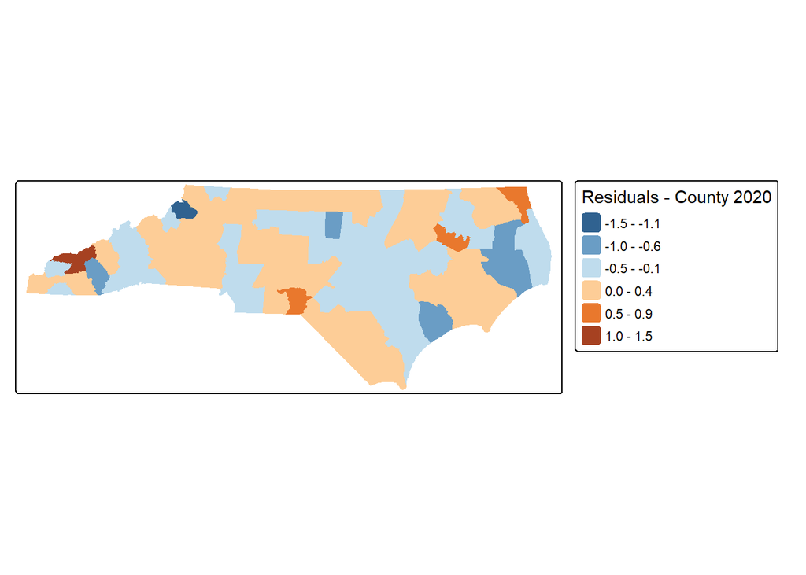

```r
nc_health_map$resids <- first.model.county$residuals

tm_shape(nc_health_map) +
  tm_polygons(fill="resids", col=NULL,
              fill.scale = tm_scale_intervals(midpoint=0, values="-tableau.orange_blue_white_diverging"),
              fill.legend = tm_legend("Residuals - County 2020",
                                      position=tm_pos_out(pos.h="right")))
```

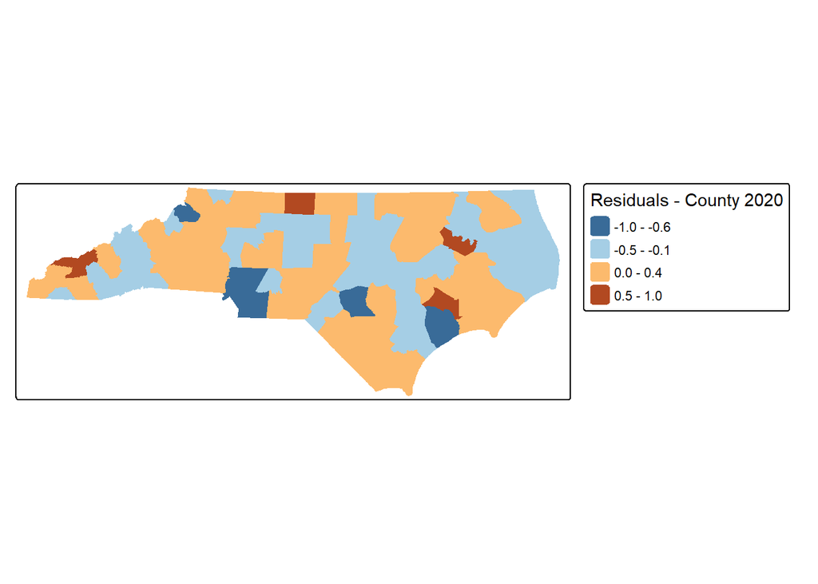

```r
nc_health_map$resids <- second.model.county$residuals

tm_shape(nc_health_map) +
  tm_polygons(fill="resids", col=NULL,
              fill.scale = tm_scale_intervals(midpoint=0, values="-tableau.orange_blue_white_diverging"),
              fill.legend = tm_legend("Residuals - County 2020",
                                      position=tm_pos_out(pos.h="right")))
```

The residuals are much different, as expected.

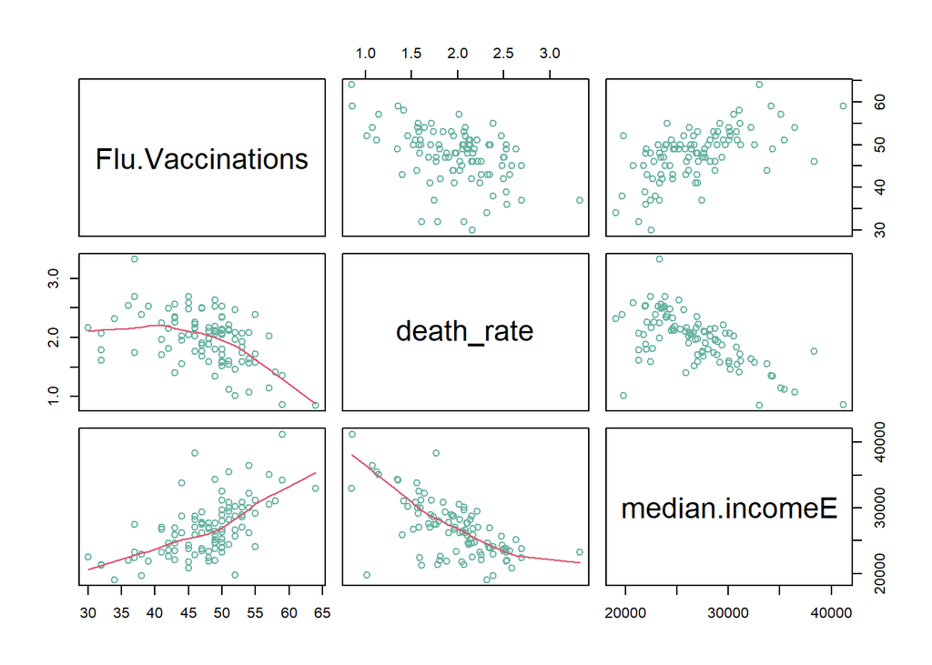

```r
as.data.frame(nc_health_map) |>
  select(Flu.Vaccinations,
         death_rate, median.incomeE) |>
  pairs(col="#69b3a2", lower.panel=panel.smooth)
```

# Results

Finally, the actual linear regression part across all three variables.

```r
second.model.county <- lm(death_rate ~
                            Flu.Vaccinations + median.incomeE,
                          data=nc_health_map)
summary(second.model.county)
```

```
##
## Call:
## lm(formula = death_rate ~ Flu.Vaccinations + median.incomeE,
##     data = nc_health_map)
##
## Residuals:
##      Min       1Q   Median       3Q      Max
## -1.32346 -0.18928  0.03673  0.20644  1.05513
##
## Coefficients:
##                    Estimate Std. Error t value Pr(>|t|)
## (Intercept)       3.919e+00  2.648e-01  14.801  < 2e-16 ***
## Flu.Vaccinations -8.401e-03  6.670e-03  -1.259    0.211
## median.incomeE   -5.763e-05  9.956e-06  -5.789 8.71e-08 ***
## ---
## Signif. codes:  0 '***' 0.001 '**' 0.01 '*' 0.05 '.' 0.1 ' ' 1
##
## Residual standard error: 0.3324 on 97 degrees of freedom
## Multiple R-squared:  0.4169, Adjusted R-squared:  0.4049
## F-statistic: 34.67 on 2 and 97 DF,  p-value: 4.359e-12
```

# Conclusion

# References

*HHS winds down mrna vaccine development under Barda*. HHS Winds Down mRNA Vaccine Development Under BARDA | HHS.gov. (2025, August 5). https://www.hhs.gov/press-room/hhs-winds-down-mrna-development-under-barda.html

Matveeva, O., Ogurtsov, A. Y., & Shabalina, S. A. (2024, August 12). *Impact of vaccination rates, pre-pandemic life expectancy, economic status and age on covid-19 excess mortality across United States*. medRxiv : the preprint server for health sciences. https://pmc.ncbi.nlm.nih.gov/articles/PMC10836123/

*Vaccines: The myths and the facts*. American Academy of Allergy Asthma & Immunology. (2025, October 2). https://www.aaaai.org/tools-for-the-public/conditions-library/allergies/vaccine-myth-fact